# DTSC 560 - Logistic Regression Analysis

## Importing all the necessary packages

## Loading the data

The percentage of customers have submitted a recent claim is $26\%$

**2) Partition the dataset into a training, validation, and test set, using a 60%-20%-20% split.** Quiz question #2: How many observations are in the test set?

```
Rows: 1,447
Columns: 19
$ CLAIM      <dbl> 0, 1, 0, 0, 0, 0, 1, 0, 0, 0, 0, 0, 1, 1, 0, 0, 0, 0, 0, 0, 0, 0, 0, 0, 0,…
$ KIDSDRIV   <dbl> 0, 0, 0, 0, 0, 0, 0, 0, 0, 0, 0, 0, 0, 0, 0, 0, 0, 0, 0, 0, 0, 1, 0, 0, 0,…
$ AGE        <dbl> 50, 45, 39, 31, 33, 52, 33, 63, 49, 44, 54, 55, 33, 41, 37, 47, 33, 36, 55…
$ HOMEKIDS   <dbl> 0, 0, 1, 1, 1, 0, 1, 0, 0, 1, 0, 0, 1, 1, 0, 0, 1, 1, 0, 0, 0, 1, 0, 1, 0,…
$ INCOME     <dbl> 114986, 0, 51884, 18903, 79606, 51278, 20822, 74426, 0, 139330, 71007, 457…
$ HOMEOWN    <dbl> 1, 1, 1, 1, 1, 1, 1, 0, 1, 1, 1, 1, 0, 0, 1, 1, 1, 0, 0, 1, 1, 0, 1, 1, 0,…
$ MSTATUS    <dbl> 1, 1, 0, 1, 1, 1, 1, 0, 1, 0, 1, 1, 0, 0, 1, 1, 1, 0, 0, 0, 0, 0, 1, 1, 0,…
$ GENDER     <dbl> 1, 1, 1, 1, 1, 1, 1, 1, 1, 1, 0, 1, 0, 1, 1, 0, 1, 1, 0, 1, 1, 1, 0, 0, 0,…
$ EDUCATION  <dbl> 1, 0, 1, 0, 1, 1, 0, 1, 1, 0, 1, 1, 0, 1, 1, 1, 1, 0, 0, 1, 1, 1, 0, 1, 0,…
$ TRAVTIME   <dbl> 36, 48, 43, 48, 27, 37, 46, 11, 42, 35, 61, 5, 14, 34, 29, 40, 35, 38, 33,…
$ CAR_USE    <dbl> 0, 0, 0, 0, 0, 0, 0, 0, 0, 1, 0, 0, 1, 1, 0, 1, 1, 0, 0, 0, 0, 0, 0, 0, 1,…
$ BLUEBOOK   <dbl> 18000, 6000, 10590, 17330, 16830, 1500, 6880, 27600, 6400, 22050, 14000, 1…
$ TWC        <dbl> 1, 1, 6, 4, 9, 4, 13, 1, 10, 10, 6, 6, 1, 3, 1, 4, 1, 1, 4, 10, 4, 7, 10, …
$ RED_CAR    <dbl> 0, 0, 0, 0, 0, 0, 0, 0, 0, 0, 0, 0, 1, 0, 0, 1, 0, 0, 0, 0, 0, 0, 1, 1, 1,…
$ CLM_BEF    <dbl> 1, 0, 0, 0, 0, 0, 1, 0, 1, 0, 0, 0, 1, 0, 0, 0, 0, 0, 0, 1, 0, 1, 0, 0, 0,…
$ REVOKED    <dbl> 1, 0, 0, 0, 0, 0, 0, 0, 0, 0, 0, 0, 0, 0, 0, 0, 0, 0, 0, 0, 0, 0, 0, 0, 0,…
$ MVR_PTS    <dbl> 1, 1, 0, 0, 1, 1, 0, 0, 1, 0, 0, 0, 1, 1, 0, 0, 1, 0, 0, 1, 1, 1, 0, 1, 1,…
$ CAR_AGE    <dbl> 17, 5, 13, 7, 15, 10, 1, 18, 14, 1, 11, 13, 5, 18, 10, 11, 4, 1, 1, 10, 14…
$ URBANICITY <dbl> 1, 1, 0, 1, 0, 1, 1, 1, 1, 0, 1, 1, 1, 1, 1, 1, 1, 0, 0, 1, 1, 1, 1, 1, 0,…
```

**3) We don’t have a severe class imbalance in the insurance dataset, so we’re going to start with fitting a model to the training set. Conduct a logistic regression analysis using the training data frame with CLAIM as the outcome variable and all the other variables in the dataset as predictor variables.**

```
Call:
glm(formula = CLAIM ~ ., family = "binomial", data = train)

Coefficients:
              Estimate Std. Error z value Pr(>|z|)
(Intercept) -2.798e+00  3.439e-01  -8.136 4.09e-16 ***
KIDSDRIV     6.928e-01  1.330e-01   5.210 1.89e-07 ***
AGE         -2.906e-03  5.532e-03  -0.525  0.59942
HOMEKIDS     3.226e-01  1.108e-01   2.912  0.00359 **
INCOME      -5.172e-06  1.124e-06  -4.601 4.20e-06 ***
HOMEOWN     -2.619e-01  9.693e-02  -2.702  0.00690 **
MSTATUS     -7.306e-01  9.690e-02  -7.540 4.69e-14 ***
GENDER       1.581e-01  1.098e-01   1.439  0.15009
EDUCATION   -5.170e-01  1.113e-01  -4.647 3.36e-06 ***
TRAVTIME     1.659e-02  2.582e-03   6.426 1.31e-10 ***
CAR_USE      9.752e-01  8.747e-02  11.148  < 2e-16 ***
BLUEBOOK    -3.224e-05  5.477e-06  -5.887 3.93e-09 ***
TWC         -5.240e-02  1.005e-02  -5.216 1.83e-07 ***
RED_CAR     -1.193e-01  1.165e-01  -1.024  0.30591
CLM_BEF      6.248e-01  8.365e-02   7.469 8.07e-14 ***
REVOKED      6.592e-01  1.095e-01   6.019 1.75e-09 ***
MVR_PTS      4.006e-01  8.609e-02   4.653 3.27e-06 ***
CAR_AGE     -8.217e-05  9.252e-03  -0.009  0.99291
URBANICITY   2.257e+00  1.561e-01  14.454  < 2e-16 ***
---
Signif. codes:  0 ‘***’ 0.001 ‘**’ 0.01 ‘*’ 0.05 ‘.’ 0.1 ‘ ’ 1

(Dispersion parameter for binomial family taken to be 1)

    Null deviance: 5007.9  on 4338  degrees of freedom
Residual deviance: 3914.9  on 4320  degrees of freedom
AIC: 3952.9

Number of Fisher Scoring iterations: 5

The odd ratio:
            odds_ratios
(Intercept)  0.06095287
KIDSDRIV     1.99926456
AGE          0.99709858
HOMEKIDS     1.38073472
INCOME       0.99999483
HOMEOWN      0.76960179
MSTATUS      0.48161757
GENDER       1.17124636
EDUCATION    0.59629965
TRAVTIME     1.01672903
CAR_USE      2.65157745
BLUEBOOK     0.99996776
TWC          0.94895171
RED_CAR      0.88754976
CLM_BEF      1.86780633
REVOKED      1.93332042
MVR_PTS      1.49272520
CAR_AGE      0.99991784
URBANICITY   9.55088633
```

Quiz question #3: What is the coefficient for the KIDSDRIV variable?

Quiz question #4: What is the odds ratio for the URBANICITY variable?

The odds ratio for the URBANICITY variable is approximately 9.5509

Quiz question #5: How would you interpret the odds ratio for the URBANICITY variable? (MC)

The URBANICITY variable odds ratio means that a customer who lives in an urban has made a recent auto insurance claim 9.5509 times more than customers living in rural area.

**4) Using the model you fitted in Step (3) and the validation data frame you created in Step (2), create a confusion matrix to assess the accuracy of the logistic regression model.**

```
Confusion Matrix and Statistics


predicted_classes   0   1
                0 984 255
                1  81 126

               Accuracy : 0.7676
                 95% CI : (0.745, 0.7892)
    No Information Rate : 0.7365
    P-Value [Acc > NIR] : 0.003605

                  Kappa : 0.2984

 Mcnemar's Test P-Value : < 2.2e-16

            Sensitivity : 0.9239
            Specificity : 0.3307
         Pos Pred Value : 0.7942
         Neg Pred Value : 0.6087
             Prevalence : 0.7365
         Detection Rate : 0.6805
   Detection Prevalence : 0.8568
      Balanced Accuracy : 0.6273

       'Positive' Class : 0
```

Quiz question #6: How many insurance claims (positives) did the model predict correctly?

Quiz question #7: What is the accuracy rate? The accuracy rate is 0.7676

Quiz question #8: What is the sensitivity? The sensitivity is 0.9239

**5) Again using the model you fitted in Step (3) and the validation data frame, create an ROC curve plot and calculate the AUC.**

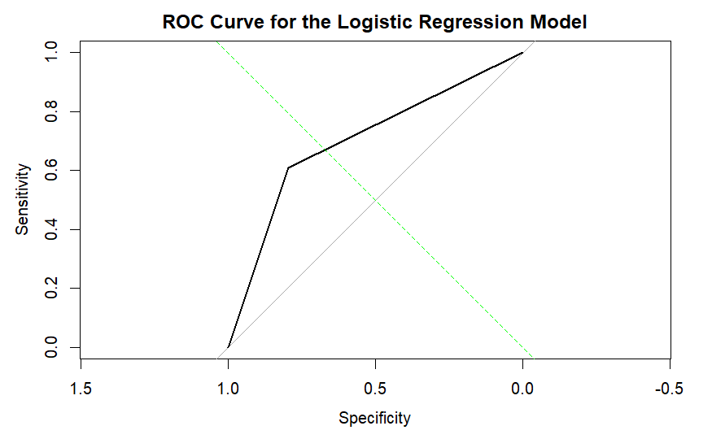

```
AUC: 0.7014423
```

Quiz question #10: What is the AUC?

AUC = 0.7014423

**6) Even though we do not have a severe class imbalance in our data, let’s try addressing our moderate class imbalance to see if it improves our model accuracy. Using the training set you generated in Step (2), create a new training subset using the oversampling method.**

```
   0    1
3194 3194
```

Quiz question #11: In this new training subset generated from oversampling, how many observations are in the class that has made a recent auto claim (“Yes”)?

3194 observations are in the class that has made a recent auto claim (“Yes”)

**7) Conduct a logistic regression analysis using the new oversampled training subset with CLAIM as the outcome variable and all the other variables in the dataset as predictor variables.**

```
Call:
glm(formula = CLAIM ~ ., family = "binomial", data = data_balanced_over)

Coefficients:
              Estimate Std. Error z value Pr(>|z|)
(Intercept) -2.296e+00  2.468e-01  -9.305  < 2e-16 ***
KIDSDRIV     8.120e-01  1.046e-01   7.763 8.31e-15 ***
AGE         -8.114e-05  3.959e-03  -0.020 0.983649
HOMEKIDS     3.133e-01  8.353e-02   3.751 0.000176 ***
INCOME      -4.723e-06  8.039e-07  -5.875 4.22e-09 ***
HOMEOWN     -2.053e-01  7.402e-02  -2.774 0.005545 **
MSTATUS     -7.166e-01  7.374e-02  -9.718  < 2e-16 ***
GENDER       2.727e-01  8.320e-02   3.278 0.001046 **
EDUCATION   -4.751e-01  8.355e-02  -5.686 1.30e-08 ***
TRAVTIME     1.906e-02  1.959e-03   9.729  < 2e-16 ***
CAR_USE      9.967e-01  6.675e-02  14.932  < 2e-16 ***
BLUEBOOK    -3.054e-05  4.014e-06  -7.607 2.80e-14 ***
TWC         -4.734e-02  7.360e-03  -6.432 1.26e-10 ***
RED_CAR      6.196e-02  8.709e-02   0.711 0.476792
CLM_BEF      6.131e-01  6.226e-02   9.849  < 2e-16 ***
REVOKED      5.673e-01  8.669e-02   6.544 6.00e-11 ***
MVR_PTS      3.549e-01  6.290e-02   5.643 1.67e-08 ***
CAR_AGE     -4.341e-03  6.799e-03  -0.638 0.523159
URBANICITY   2.385e+00  1.099e-01  21.696  < 2e-16 ***
---
Signif. codes:  0 ‘***’ 0.001 ‘**’ 0.01 ‘*’ 0.05 ‘.’ 0.1 ‘ ’ 1

(Dispersion parameter for binomial family taken to be 1)

    Null deviance: 8855.6  on 6387  degrees of freedom
Residual deviance: 6830.0  on 6369  degrees of freedom
AIC: 6868

Number of Fisher Scoring iterations: 4
```

**8) Using the model you fitted in Step (7) and the validation data frame you created in Step (2), create a confusion matrix to assess the accuracy of the logistic regression model.**

```
Confusion Matrix and Statistics


predicted_classes1   0   1
                 0 767 113
                 1 298 268

               Accuracy : 0.7158
                 95% CI : (0.6918, 0.7389)
    No Information Rate : 0.7365
    P-Value [Acc > NIR] : 0.9649

                  Kappa : 0.3665

 Mcnemar's Test P-Value : <2e-16

            Sensitivity : 0.7202
            Specificity : 0.7034
         Pos Pred Value : 0.8716
         Neg Pred Value : 0.4735
             Prevalence : 0.7365
         Detection Rate : 0.5304
   Detection Prevalence : 0.6086
      Balanced Accuracy : 0.7118

       'Positive' Class : 0
```

Quiz question #12: What is the accuracy rate?

Accuracy = 0.7158

Quiz question #13: What is the sensitivity?

Sensitivity = 0.7202

**9) Again using the model you fitted in Step (7) and the validation data frame, create an ROC curve plot and calculate the AUC.**

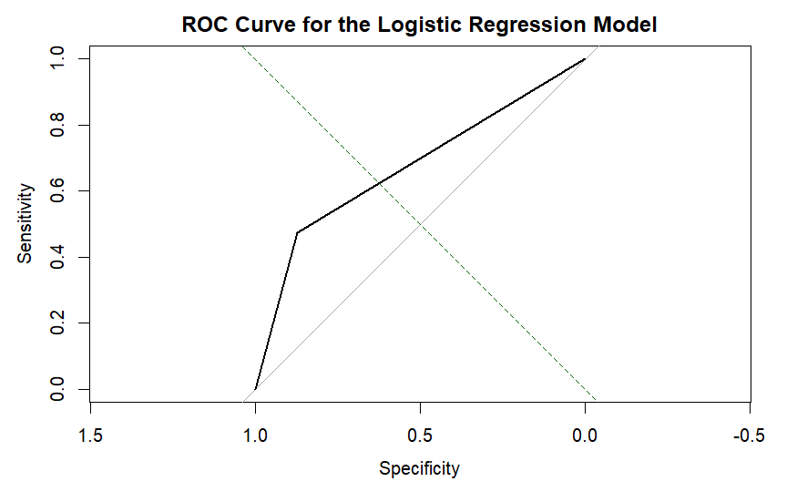

```
AUC: 0.6725446
```

Quiz question #14: What is the AUC?

AUC = 0.6725446

Quiz question #15: What do you notice about this AUC value as compared to the AUC value for the previous model? (MC)

AUC value in the second model is smaller the AUC value for the first model (0.6725 < 0.7014).

**10) Let’s say that for this insurance company, sensitivity is more important than overall accuracy and the cost of false positives is lower than the cost of false negatives, so we will use the logistic regression model fitted to the over sampled training subset.** Using the model generated in Step (7) and the test set you created in Step (2), create a confusion matrix to assess the accuracy of the logistic regression model on the test data frame.

```
Confusion Matrix and Statistics


predicted_classes2   0   1
                 0 749  99
                 1 316 283

               Accuracy : 0.7132
                 95% CI : (0.6891, 0.7364)
    No Information Rate : 0.736
    P-Value [Acc > NIR] : 0.9764

                  Kappa : 0.3757

 Mcnemar's Test P-Value : <2e-16

            Sensitivity : 0.7033
            Specificity : 0.7408
         Pos Pred Value : 0.8833
         Neg Pred Value : 0.4725
             Prevalence : 0.7360
         Detection Rate : 0.5176
   Detection Prevalence : 0.5860
      Balanced Accuracy : 0.7221

       'Positive' Class : 0
```

Quiz question #16: How many insurance claims (positives) did the model predict correctly using the test set?

Quiz question #17: What is the accuracy rate?

Accuracy = 0.7132

Quiz question #18: What is the sensitivity?

Sensitivity = 0.7033

**11) Again using the model you fitted in Step (7) and the test data frame, create an ROC curve plot and calculate the AUC.**

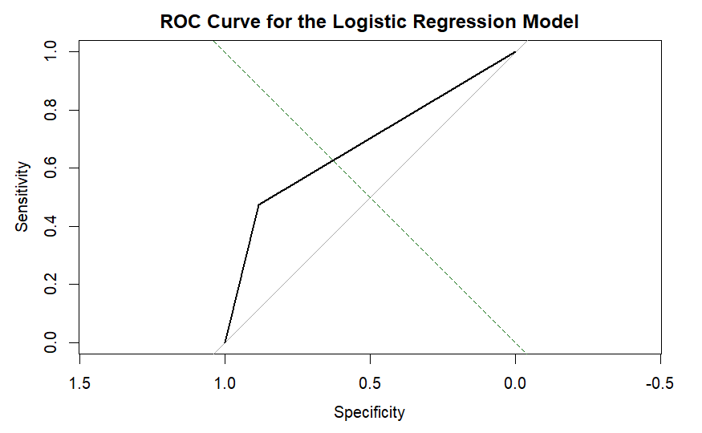

```
AUC: 0.6778544
```

Quiz question #19: What is the AUC?

AUC = 0.6779

**12) Now we’ll use the model fitted to the oversampled training subset to make predictions about whether new customers will make auto insurance claims. Using the data contained in the csv file “insurance_predictions.csv”, predict the probability scores for insurance claims for ten new customers.**

Quiz question #20: What is the predicted probability of making an insurance claim for new customer #1?

```
   predicted probability
1              0.6718234
2              0.4582157
3              0.1752649
4              0.2419807
5              0.1465592
6              0.7433227
7              0.4447522
8              0.5938372
9              0.4336353
10             0.3964417
```